# Exemplo curso de R

A. Schmidt

23 de maio de 2018

# Introdução

Este é um relatório de exemplo de uso do R Markdown. Nosso objetivo será analisar alguns dados da [RAIS](http://www.rais.gov.br/sitio/index.jsf) (Fonte: Ministério do Trabalho). Estes dados podem ser utilizados como nos trabalhos de [Bonini e Pozzobon (2016)](http://www.seer.ufrgs.br/AnaliseEconomica/article/download/52900/38611) ou [Schmidt (2017)](http://sistemabu.udesc.br/pergamumweb/vinculos/000042/000042c2.pdf), que é o trabalho no qual iremos basear nossa análise para fazer as estatísticas descritivas.

## Carregamento dos dados

Para carregar os dados, faremos uso do pacote `foreign`, para leitura de dados em formato dta (do Stata). A função `glimpse` do pacote `dplyr` auxilia para verificar como estão os dados.

```r
library(foreign)
library(dplyr)
dadosraistisc <- read.dta("C:\\Users\\Aishameriane\\Dropbox\\Mini Curso de R - Congresso de Economia da UFSC 2018\\Dados\\dadosraistisc.dta")
head(dadosraistisc)
```

```
##   cboocupao2002 cnae20classe vnculoativo3112 escolaridadeaps2005
## 1        212405        26523               1                   7
## 2        212405        26515               1                   7
## 3        212405        26213               1                   7
## 4        212405        26329               1                   7
## 5        212405        26329               1                   7
## 6        212405        26329               1                   7
##   qtdhoracontr idade municpio vlremunmdianom cnae20subclasse sexo tempemp
## 1           40    31   420540        1285.22         2652300    1    10.5
## 2           44    23   420540        2709.75         2651500    1     9.9
## 3            2    30   421660         509.84         2621300    1     0.9
## 4           40    28   420540        4151.76         2632900    1    67.2
## 5           40    24   420540        1829.48         2632900    1    11.6
## 6           40    31   420540        2286.07         2632900    1    37.9
##       salhr   lnsalh idade2 sgc mdio supinc sup mes dout pos
## 1  32.13050 3.469806    961   0    1      0   0   0    0   0
## 2  61.58523 4.120422    529   0    1      0   0   0    0   0
## 3 254.92000 5.540950    900   0    1      0   0   0    0   0
## 4 103.79399 4.642408    784   0    1      0   0   0    0   0
## 5  45.73700 3.822908    576   0    1      0   0   0    0   0
## 6  57.15175 4.045710    961   0    1      0   0   0    0   0
```

```r
glimpse(dadosraistisc)
```

```
## Observations: 4,352
## Variables: 21
## $ cboocupao2002       <int> 212405, 212405, 212405, 212405, 212405, 21...
## $ cnae20classe        <int> 26523, 26515, 26213, 26329, 26329, 26329, ...
## $ vnculoativo3112     <int> 1, 1, 1, 1, 1, 1, 1, 1, 1, 1, 1, 1, 1, 1, ...
## $ escolaridadeaps2005 <int> 7, 7, 7, 7, 7, 7, 8, 8, 8, 8, 8, 8, 8, 9, ...
## $ qtdhoracontr        <int> 40, 44, 2, 40, 40, 40, 44, 44, 44, 44, 30,...
## $ idade               <int> 31, 23, 30, 28, 24, 31, 34, 28, 31, 37, 21...
## $ municpio            <int> 420540, 420540, 421660, 420540, 420540, 42...
## $ vlremunmdianom      <dbl> 1285.22, 2709.75, 509.84, 4151.76, 1829.48...
## $ cnae20subclasse     <int> 2652300, 2651500, 2621300, 2632900, 263290...
## $ sexo                <int> 1, 1, 1, 1, 1, 1, 1, 1, 1, 1, 1, 1, 1, 1, ...
## $ tempemp             <dbl> 10.5, 9.9, 0.9, 67.2, 11.6, 37.9, 21.7, 72...
## $ salhr               <dbl> 32.13050, 61.58523, 254.92000, 103.79399, ...
## $ lnsalh              <dbl> 3.469806, 4.120422, 5.540950, 4.642408, 3....
## $ idade2              <dbl> 961, 529, 900, 784, 576, 961, 1156, 784, 9...
## $ sgc                 <dbl> 0, 0, 0, 0, 0, 0, 0, 0, 0, 0, 0, 0, 0, 0, ...
## $ mdio                <dbl> 1, 1, 1, 1, 1, 1, 0, 0, 0, 0, 0, 0, 0, 0, ...
## $ supinc              <dbl> 0, 0, 0, 0, 0, 0, 1, 1, 1, 1, 1, 1, 1, 0, ...
## $ sup                 <dbl> 0, 0, 0, 0, 0, 0, 0, 0, 0, 0, 0, 0, 0, 1, ...
## $ mes                 <dbl> 0, 0, 0, 0, 0, 0, 0, 0, 0, 0, 0, 0, 0, 0, ...
## $ dout                <dbl> 0, 0, 0, 0, 0, 0, 0, 0, 0, 0, 0, 0, 0, 0, ...
## $ pos                 <dbl> 0, 0, 0, 0, 0, 0, 0, 0, 0, 0, 0, 0, 0, 0, ...
```

```r
tail(dadosraistisc)
```

```
##      cboocupao2002 cnae20classe vnculoativo3112 escolaridadeaps2005
## 4347        212420        62031               0                   9
## 4348        212420        62031               0                   9
## 4349        212420        62031               0                   9
## 4350        212420        62015               0                   9
## 4351        212420        62015               0                   9
## 4352        212420        62015               0                   9
##      qtdhoracontr idade municpio vlremunmdianom cnae20subclasse sexo
## 4347           44    22   420240         805.97         6203100    2
## 4348           44    24   420240         810.51         6203100    2
## 4349           44    22   420240         866.74         6203100    2
## 4350           44    30   420910        1849.22         6201500    2
## 4351           44    32   420910        3199.99         6201500    2
## 4352           44    24   420910        2167.61         6201500    2
##      tempemp    salhr   lnsalh idade2 sgc mdio supinc sup mes dout pos
## 4347     6.7 18.31750 2.907857    484   0    0      0   1   0    0   0
## 4348    13.0 18.42068 2.913474    576   0    0      0   1   0    0   0
## 4349    11.2 19.69864 2.980549    484   0    0      0   1   0    0   0
## 4350    52.7 42.02773 3.738329    900   0    0      0   1   0    0   0
## 4351     1.8 72.72704 4.286713   1024   0    0      0   1   0    0   0
## 4352    34.8 49.26387 3.897191    576   0    0      0   1   0    0   0
```

```r
summary(dadosraistisc)
```

```
##  cboocupao2002     cnae20classe   vnculoativo3112  escolaridadeaps2005
##  Min.   :212405   Min.   :26213   Min.   :0.0000   Min.   : 5.000
##  1st Qu.:212405   1st Qu.:62023   1st Qu.:1.0000   1st Qu.: 9.000
##  Median :212405   Median :62031   Median :1.0000   Median : 9.000
##  Mean   :212409   Mean   :61055   Mean   :0.7845   Mean   : 8.654
##  3rd Qu.:212420   3rd Qu.:62031   3rd Qu.:1.0000   3rd Qu.: 9.000
##  Max.   :212420   Max.   :62091   Max.   :1.0000   Max.   :11.000
##
##   qtdhoracontr       idade         municpio      vlremunmdianom
##  Min.   : 2.00   Min.   :17.0   Min.   :420240   Min.   :    0
##  1st Qu.:42.00   1st Qu.:26.0   1st Qu.:420240   1st Qu.: 1850
##  Median :44.00   Median :29.0   Median :420540   Median : 2867
##  Mean   :42.23   Mean   :30.6   Mean   :420625   Mean   : 3285
##  3rd Qu.:44.00   3rd Qu.:34.0   3rd Qu.:420910   3rd Qu.: 4262
##  Max.   :44.00   Max.   :72.0   Max.   :421660   Max.   :35972
##
##  cnae20subclasse        sexo          tempemp           salhr
##  Min.   :2621300   Min.   :1.000   Min.   :  0.00   Min.   :   0.00
##  1st Qu.:6202300   1st Qu.:1.000   1st Qu.:  9.70   1st Qu.:  43.60
##  Median :6203100   Median :1.000   Median : 17.00   Median :  68.10
##  Mean   :6105502   Mean   :1.239   Mean   : 34.87   Mean   :  88.91
##  3rd Qu.:6203100   3rd Qu.:1.000   3rd Qu.: 37.20   3rd Qu.:  98.96
##  Max.   :6209100   Max.   :2.000   Max.   :436.50   Max.   :1512.91
##
##      lnsalh          idade2            sgc         mdio
##  Min.   :1.382   Min.   : 289.0   Min.   :0   Min.   :0.00000
##  1st Qu.:3.782   1st Qu.: 676.0   1st Qu.:0   1st Qu.:0.00000
##  Median :4.223   Median : 841.0   Median :0   Median :0.00000
##  Mean   :4.205   Mean   : 991.2   Mean   :0   Mean   :0.07583
##  3rd Qu.:4.596   3rd Qu.:1156.0   3rd Qu.:0   3rd Qu.:0.00000
##  Max.   :7.322   Max.   :5184.0   Max.   :0   Max.   :1.00000
##  NA's   :24
##      supinc            sup              mes                dout
##  Min.   :0.0000   Min.   :0.0000   Min.   :0.000000   Min.   :0.000000
##  1st Qu.:0.0000   1st Qu.:0.0000   1st Qu.:0.000000   1st Qu.:0.000000
##  Median :0.0000   Median :1.0000   Median :0.000000   Median :0.000000
##  Mean   :0.1611   Mean   :0.7417   Mean   :0.006893   Mean   :0.006893
##  3rd Qu.:0.0000   3rd Qu.:1.0000   3rd Qu.:0.000000   3rd Qu.:0.000000
##  Max.   :1.0000   Max.   :1.0000   Max.   :1.000000   Max.   :1.000000
##
##       pos
##  Min.   :0.00000
##  1st Qu.:0.00000
##  Median :0.00000
##  Mean   :0.01379
##  3rd Qu.:0.00000
##  Max.   :2.00000
##
```

E se quisermos salvar em csv?

```r
write.csv(dadosraistisc, "C:\\Users\\Aishameriane\\Dropbox\\Mini Curso de R - Congresso de Economia da UFSC 2018\\Dados\\dadosraistisc.csv")
```

## Tratamento dos dados

Existem 24 observações faltantes na coluna do logaritmo do salário hora. Iremos usar a função `complete.cases` para removê-las, mas primeiro vamos criar uma variável que tenha os dados para evitar ter que carregá-los novamente caso algo dê errado. Além disso, vamos ficar apenas com algumas colunas selecionadas: * ln do salário hora; * se a pessoa tem ensino superior incompleto; * se a pessoa tem ensino superior completo; * se a pessoa tem pós graduação; * idade, em anos; * idade ao quadrado; * tempo de emprego, em meses; * gênero (masc/feminino).

```r
dados <- cbind(dadosraistisc$lnsalh, dadosraistisc[,c(17,18,21,6,14,11,10)])
dados <- data.frame(dados)
dados <- dados[complete.cases(dados),]
colnames(dados) <- c("lnsalh", "supinc", "sup", "pos", "idade", "idade2", "tempemp", "genero")
summary(dados)
```

```
##      lnsalh          supinc            sup              pos
##  Min.   :1.382   Min.   :0.0000   Min.   :0.0000   Min.   :0.00000
##  1st Qu.:3.782   1st Qu.:0.0000   1st Qu.:0.0000   1st Qu.:0.00000
##  Median :4.223   Median :0.0000   Median :1.0000   Median :0.00000
##  Mean   :4.205   Mean   :0.1613   Mean   :0.7412   Mean   :0.01386
##  3rd Qu.:4.596   3rd Qu.:0.0000   3rd Qu.:1.0000   3rd Qu.:0.00000
##  Max.   :7.322   Max.   :1.0000   Max.   :1.0000   Max.   :2.00000
##      idade           idade2          tempemp           genero
##  Min.   :17.00   Min.   : 289.0   Min.   :  0.10   Min.   :1.000
##  1st Qu.:26.00   1st Qu.: 676.0   1st Qu.:  9.70   1st Qu.:1.000
##  Median :29.00   Median : 841.0   Median : 16.95   Median :1.000
##  Mean   :30.57   Mean   : 988.4   Mean   : 34.55   Mean   :1.239
##  3rd Qu.:34.00   3rd Qu.:1156.0   3rd Qu.: 36.92   3rd Qu.:1.000
##  Max.   :72.00   Max.   :5184.0   Max.   :433.40   Max.   :2.000
```

```r
sd(dados[,1])
```

```
## [1] 0.6930944
```

Nós vamos querer que a variável de gênero assuma valor 1 para mulheres e 0 para homens (atualmente está 1 para homem e 2 para mulher). A mesma coisa para a dummy (variável binária) que indica se a pessoa tem pós graduação.

```r
dados$genero[dados$genero == 1] <- 0
dados$genero[dados$genero == 2] <- 1

dados$pos[dados$pos == 2] <- 1
```

## Estatísticas descritivas

Iremos fazer algumas tabelas simples de frequências para as variáveis qualitativas e calcular as estatísticas descritivas para as variáveis quantitativas.

```r
summary(dados[,"idade"])
```

```
##    Min. 1st Qu.  Median    Mean 3rd Qu.    Max.
##   17.00   26.00   29.00   30.57   34.00   72.00
```

```r
sd(dados[,"idade"])
```

```
## [1] 7.352563
```

```r
nrow(dados)
```

```
## [1] 4328
```

```r
summary(dados[,"idade2"])
```

```
##    Min. 1st Qu.  Median    Mean 3rd Qu.    Max.
##   289.0   676.0   841.0   988.4  1156.0  5184.0
```

```r
sd(dados[,"idade2"])
```

```
## [1] 527.0694
```

```r
summary(dados[,"tempemp"])
```

```
##    Min. 1st Qu.  Median    Mean 3rd Qu.    Max.
##    0.10    9.70   16.95   34.55   36.92  433.40
```

```r
sd(dados[,"tempemp"])
```

```
## [1] 54.2018
```

```r
summary(dados[,"lnsalh"])
```

```
##    Min. 1st Qu.  Median    Mean 3rd Qu.    Max.
##   1.382   3.782   4.223   4.205   4.596   7.322
```

```r
sd(dados[,"lnsalh"])
```

```
## [1] 0.6930944
```

```r
table(dados[,"genero"])
```

```
##
##    0    1
## 3292 1036
```

```r
round(table(dados[,"genero"])/nrow(dados), 4)
```

```
##
##      0      1
## 0.7606 0.2394
```

```r
table(dados[,"supinc"])
```

```
##
##    0    1
## 3630  698
```

```r
round(table(dados[,"supinc"])/nrow(dados), 4)
```

```
##
##      0      1
## 0.8387 0.1613
```

```r
table(dados[,"sup"])
```

```
##
##    0    1
## 1120 3208
```

```r
round(table(dados[,"sup"])/nrow(dados), 4)
```

```
##
##      0      1
## 0.2588 0.7412
```

```r
table(dados[,"pos"])
```

```
##
##    0    1
## 4298   30
```

```r
round(table(dados[,"pos"])/nrow(dados), 4)
```

```
##
##      0      1
## 0.9931 0.0069
```

O pacote [`stargazer`](https://cran.r-project.org/web/packages/stargazer/vignettes/stargazer.pdf) pode tanto criar tabelas em latex ou html.

```r
library(stargazer)
quantitativas <- data.frame(dados[,"idade"], dados[, "lnsalh"])
stargazer(quantitativas, type = "html")
```

| Statistic | N | Mean | St. Dev. | Min | Max |
| --- | --- | --- | --- | --- | --- |
| dados….idade.. | 4,328 | 30.567 | 7.353 | 17 | 72 |
| dados….lnsalh.. | 4,328 | 4.205 | 0.693 | 1.382 | 7.322 |

## Gráficos

- Para duas variáveis **quantitativas**, podemos usar um gráfico de *dispersão*;
- Para uma variável **quantitativa** e uma *qualitativa*, podemos usar box plots.

Iremos usar os recursos básicos de plotagem do R, através da função `plot()`.

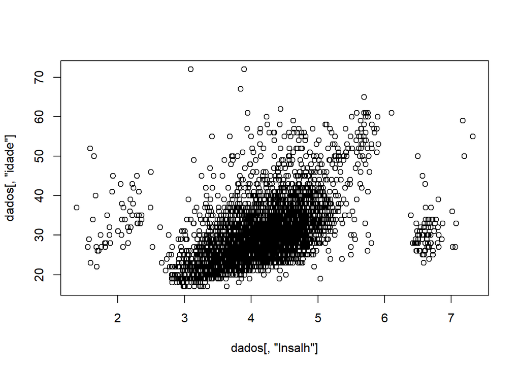

```r
plot(dados[, "lnsalh"], dados[, "idade"])
```

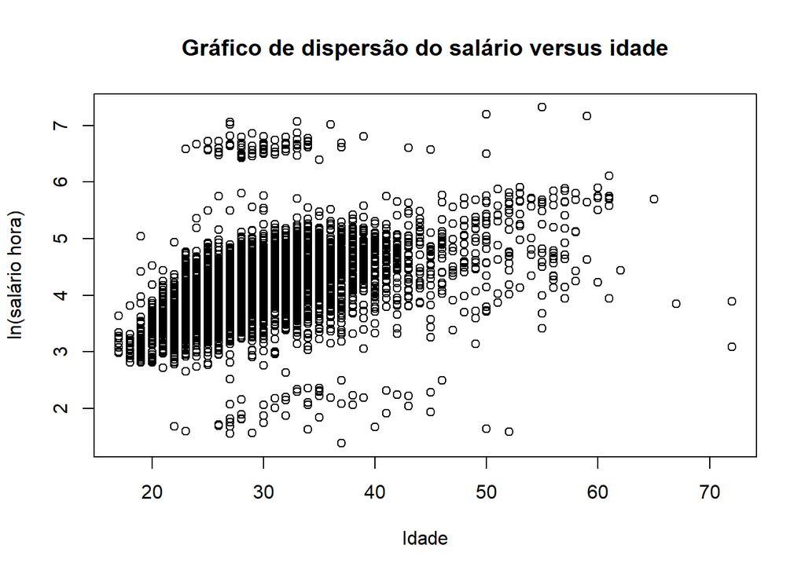

```r
plot(dados[, "idade"], dados[, "lnsalh"], xlab = "Idade", ylab = "ln(salário hora)", main = "Gráfico de dispersão do salário versus idade")
```

Podemos ainda usar recursos gráficos mais modernos para fazer o mesmo gráfico.

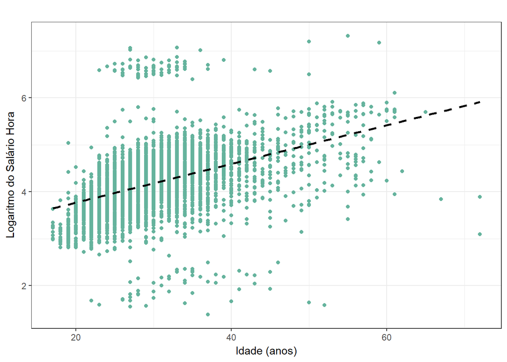

```r
library(ggplot2)

p <- ggplot(as.data.frame(dados), aes(idade, lnsalh)) +
  geom_point(color = "#65b39d") +
  geom_smooth(method=lm, se=FALSE, linetype="dashed", color="black") +
  labs(title="", x = "Idade (anos)", y= "Logaritmo do Salário Hora") +
  theme_bw()
p
```

E agora vamos fazer dois boxplots, comparando o salário de homens e mulheres.

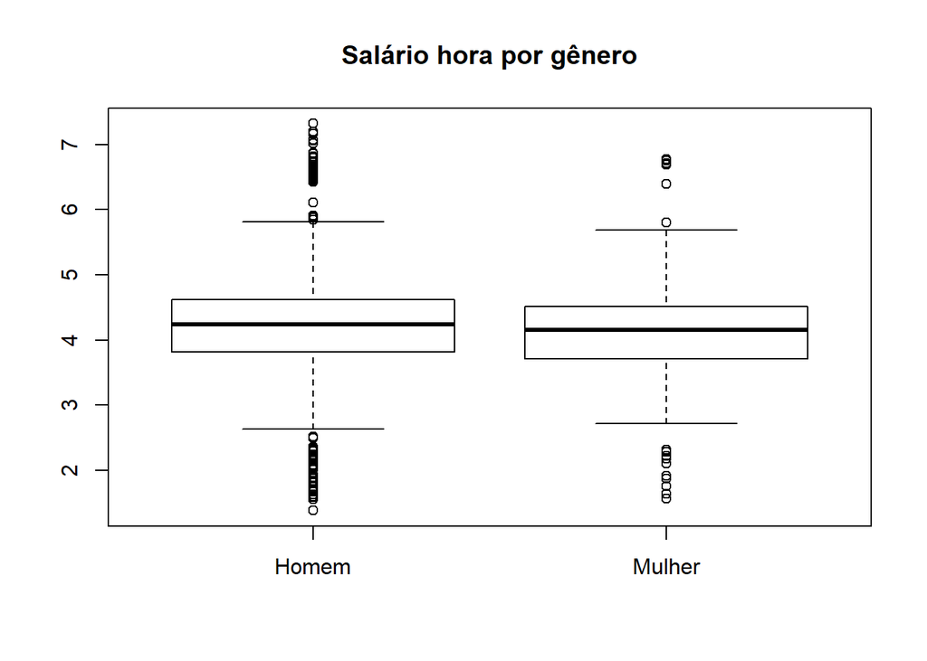

```r
boxplot(dados$lnsalh ~ dados$genero, names = c("Homem", "Mulher"), main = "Salário hora por gênero")
```

Podemos usar o `ggplot2` novamente.

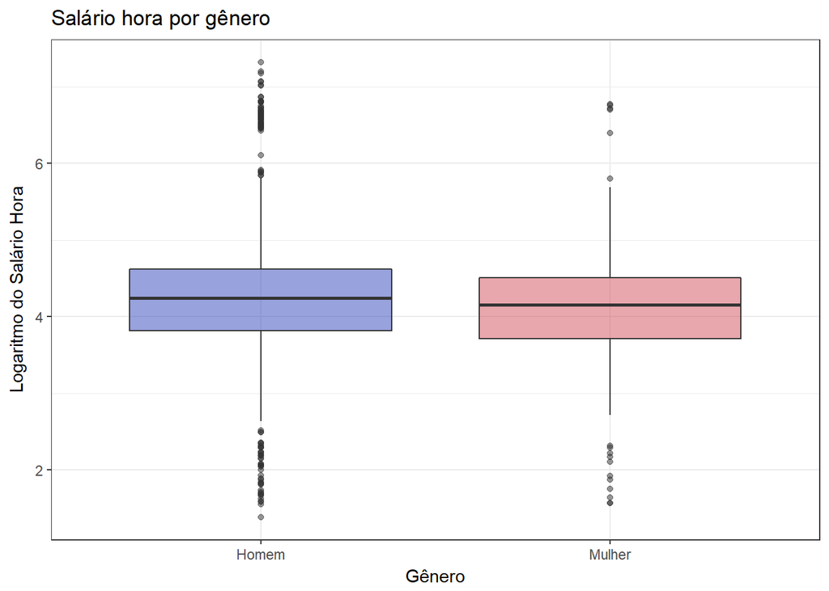

```r
p <- ggplot(dados, aes(factor(genero),lnsalh, fill=factor(genero))) +
  geom_boxplot(alpha = 0.5) +
  ggtitle("Salário hora por gênero") +
  scale_fill_manual(values = c("#3146bc", "#d14f5a"), name = "", labels = c("Homem", "Mulher")) +
  scale_x_discrete(breaks=c(0,1), labels = c("Homem", "Mulher")) +
  labs(y = "Logaritmo do Salário Hora", x= "Gênero") +
  theme_bw()
p <-p + theme(legend.position="none")
p
```